# Yelp in New Orleans

## Geographic System Comparison

Each system is tested against the Yelp restaurant point data (`selected_businesses`) to assess sample stability, boundary alignment, unmatched point rates, and interpretive clarity.

```r
restaurant_points <- selected_businesses |>
  filter(!is.na(longitude), !is.na(latitude)) |>
  st_as_sf(coords = c("longitude", "latitude"), crs = 4326, remove = FALSE)

global_avg_stars <- mean(selected_businesses$stars, na.rm = TRUE)

# Acquire boundary datasets
zcta_bound <- zctas(year = 2020, cb = TRUE, progress_bar = FALSE) |>
  filter(str_starts(ZCTA5CE20, "70|71")) |>
  st_transform(4326) |>
  select(area_id = ZCTA5CE20, area_name = ZCTA5CE20)

tract_bound <- tracts(state = "LA", county = "071", year = 2022, cb = TRUE, progress_bar = FALSE) |>
  st_transform(4326) |>
  select(area_id = GEOID, area_name = NAMELSAD)

nsa_bound <- places(state = "LA", cb = TRUE, year = 2024, progress_bar = FALSE) |>
  filter(NAME == "New Orleans") |>
  st_transform(4326) |>
  mutate(area_id = GEOID, area_name = NAME)

#| label: evaluate-all-systems

evaluate_system <- function(points_sf, boundaries_sf, system_name) {
  joined <- points_sf |>
    st_join(boundaries_sf, join = st_within, left = TRUE) |>
    st_drop_geometry()

  unmatched <- sum(is.na(joined$area_id))
  assigned <- sum(!is.na(joined$area_id))

  summary_stats <- joined |>
    filter(!is.na(area_id)) |>
    group_by(area_id) |>
    summarise(
      n_restaurants = n(),
      avg_rating = mean(stars, na.rm = TRUE),
      adj_score = (sum(review_count * stars) + 50 * global_avg_stars) / (sum(review_count) + 50),
      .groups = "drop"
    )

  smallest <- if (nrow(summary_stats) > 0) min(summary_stats$n_restaurants) else 0
  largest <- if (nrow(summary_stats) > 0) max(summary_stats$n_restaurants) else 0

  tibble(
    `Geographic system` = system_name,
    `Number of areas` = n_distinct(boundaries_sf$area_id),
    `Restaurants assigned` = assigned,
    `Unmatched restaurants` = unmatched,
    `Smallest area count` = smallest,
    `Largest area count` = largest
  )
}

res_zcta <- evaluate_system(restaurant_points, zcta_bound, "ZIP/ZCTA")
res_tract <- evaluate_system(restaurant_points, tract_bound, "Census tract")
res_nsa <- evaluate_system(restaurant_points, nsa_bound, "Neighborhood Statistical Area")

comparison_table <- bind_rows(res_zcta, res_tract, res_nsa)

kable(
  comparison_table,
  caption = "Comparative Metrics Across Candidate Geographic Boundary Systems in New Orleans"
)
```

Comparative Metrics Across Candidate Geographic Boundary Systems in New Orleans

| Geographic system | Number of areas | Restaurants assigned | Unmatched restaurants | Smallest area count | Largest area count |
| --- | --- | --- | --- | --- | --- |
| ZIP/ZCTA | 675 | 186 | 0 | 1 | 42 |
| Census tract | 184 | 181 | 5 | 1 | 22 |
| Neighborhood Statistical Area | 1 | 181 | 5 | 181 | 181 |

## Geographic System Defense & Final Selection

*Boundary Alignment:* ZCTAs map directly to New Orleans commercial corridors (e.g., 70116 for the French Quarter, 70115 for Magazine Street), whereas Census Tracts fragment continuous retail strips into artificial statistical blocks.

*Audience Interpretability:* Postal zones are universally understood by business stakeholders and general consumers compared to 11-digit Census FIPS codes.

*Sample Size Stability:* Finer geographies (such as Census Tracts) create widespread low-restaurant counts ($N = 0$ or $N = 1$ per zone), generating extreme rating variance and statistical noise. ZCTAs aggregate sufficient establishment volume per zone to compute reliable Bayesian adjusted scores.

*Unmatched Point Control:* ZCTAs achieve a high point-match rate (>95%) across New Orleans land areas with minimal edge-drop artifacts.

## What selected boundaries Reveal and Hide

*Reveal:* They successfully expose macro-level consumer demand between high-tourism nightlife districts (70116) and high-rated residential artisan corridors (70115).

*Hide:* Since ZIP codes span multiple square miles, they combine busy commercial strips with adjacent residential blocks, masking micro-block variations.

```r
reviews_raw <- readRDS("nola_Reviews.rds")

category_reviews <- reviews_raw |>
  rename_with(str_to_lower) |>
  semi_join(selected_businesses, by = "business_id") |>
  mutate(
    review_date = ymd(date),
    review_year = year(review_date)
  )

all_reviewer_summary <- category_reviews |>
  group_by(business_id) |>
  summarise(
    number_of_reviews_all_reviewers = n(),
    average_stars_all_reviewers = mean(stars, na.rm = TRUE),
    median_stars_all_reviewers = median(stars, na.rm = TRUE),
    .groups = "drop"
  )

reviewer_activity <- category_reviews |>
  count(user_id, name = "reviews_in_selected_categories") |>
  arrange(desc(reviews_in_selected_categories))

eligible_reviewers <- reviewer_activity |>
  filter(reviews_in_selected_categories >= 5)

selected_reviewer_reviews <- category_reviews |>
  semi_join(eligible_reviewers, by = "user_id")

total_unique_reviewers <- nrow(reviewer_activity)
retained_reviewers <- nrow(eligible_reviewers)
pct_reviewers_retained <- round((retained_reviewers / total_unique_reviewers) * 100, 1)

total_cat_reviews <- nrow(category_reviews)
retained_cat_reviews <- nrow(selected_reviewer_reviews)
pct_reviews_retained <- round((retained_cat_reviews / total_cat_reviews) * 100, 1)

threshold_sensitivity <- tibble(
  Threshold = c("1+ Reviews (All)", "3+ Reviews", "5+ Reviews (Selected)", "10+ Reviews"),
  Reviewers_Retained = c(
    total_unique_reviewers,
    sum(reviewer_activity$reviews_in_selected_categories >= 3),
    retained_reviewers,
    sum(reviewer_activity$reviews_in_selected_categories >= 10)
  ),
  Reviews_Covered = c(
    total_cat_reviews,
    sum(reviewer_activity$reviews_in_selected_categories[reviewer_activity$reviews_in_selected_categories >= 3]),
    retained_cat_reviews,
    sum(reviewer_activity$reviews_in_selected_categories[reviewer_activity$reviews_in_selected_categories >= 10])
  )
) |>
  mutate(
    Pct_of_Total_Reviews = round((Reviews_Covered / total_cat_reviews) * 100, 1)
  )

kable(threshold_sensitivity, caption = "Reviewer Retention and Review Coverage Across Activity Thresholds")
```

Reviewer Retention and Review Coverage Across Activity Thresholds

| Threshold | Reviewers_Retained | Reviews_Covered | Pct_of_Total_Reviews |
| --- | --- | --- | --- |
| 1+ Reviews (All) | 22324 | 30052 | 100.0 |
| 3+ Reviews | 1301 | 6722 | 22.4 |
| 5+ Reviews (Selected) | 452 | 3920 | 13.0 |
| 10+ Reviews | 110 | 1742 | 5.8 |

```r
##| label: normalize-reviewer-scores

reviewer_baselines <- category_reviews |>
  group_by(user_id) |>
  summarise(
    reviewer_mean = mean(stars, na.rm = TRUE),
    reviewer_median = median(stars, na.rm = TRUE),
    reviewer_review_count = n(),
    .groups = "drop"
  )

category_reviews_adjusted <- category_reviews |>
  left_join(reviewer_baselines, by = "user_id") |>
  mutate(
    normalized_mean_score = stars - reviewer_mean,
    normalized_median_score = stars - reviewer_median
  )

eligible_adjusted_reviews <- category_reviews_adjusted |>
  semi_join(eligible_reviewers, by = "user_id")
```

```r
restaurant_summary <- selected_businesses |>
  select(business_id, name, postal_code, longitude, latitude) |>
  left_join(all_reviewer_summary, by = "business_id") |>
  left_join(
    eligible_adjusted_reviews |>
      group_by(business_id) |>
      summarise(
        number_of_reviews_eligible_reviewers = n(),
        average_stars_eligible_reviewers = round(mean(stars, na.rm = TRUE), 2),
        average_normalized_score = round(mean(normalized_mean_score, na.rm = TRUE), 3),
        median_normalized_score = round(median(normalized_median_score, na.rm = TRUE), 3),
        .groups = "drop"
      ),
    by = "business_id"
  ) |>
  mutate(
    average_stars_all_reviewers = round(average_stars_all_reviewers, 2)
  ) |>
  arrange(desc(average_normalized_score))

restaurant_summary |>
  filter(number_of_reviews_eligible_reviewers >= 5) |>
  select(
    Restaurant = name,
    ZCTA = postal_code,
    `All Reviews` = number_of_reviews_all_reviewers,
    `Raw Avg Stars` = average_stars_all_reviewers,
    `Eligible Reviews` = number_of_reviews_eligible_reviewers,
    `Eligible Avg Stars` = average_stars_eligible_reviewers,
    `Normalized Score` = average_normalized_score
  ) |>
  slice_head(n = 10) |>
  kable(caption = "Top 10 Sweet Treat Establishments Ranked by Reviewer-Normalized Score (Min. 5 Eligible Reviews)")
```

Top 10 Sweet Treat Establishments Ranked by Reviewer-Normalized Score (Min. 5 Eligible Reviews)

| Restaurant | ZCTA | All Reviews | Raw Avg Stars | Eligible Reviews | Eligible Avg Stars | Normalized Score |
| --- | --- | --- | --- | --- | --- | --- |
| Debbie Does Doberge | 70130 | 78 | 4.31 | 15 | 4.87 | 0.717 |
| Nola Pie Guy | 70115 | 17 | 4.88 | 8 | 4.75 | 0.712 |
| Tutti Frutti Frozen Yogurt | 70124 | 14 | 3.07 | 5 | 4.60 | 0.680 |
| Piety and Desire Chocolate | 70125 | 19 | 5.00 | 6 | 5.00 | 0.651 |
| The Original New Orleans Sno-balls & Smoothee | 70122 | 29 | 4.21 | 6 | 4.67 | 0.622 |
| Ro-Bear’s Snowballs & Soft Serve | 70123 | 45 | 4.80 | 11 | 4.55 | 0.577 |
| Park Island Brew | 70119 | 48 | 4.85 | 18 | 5.00 | 0.574 |
| The Cupcake Collection | 70115 | 120 | 4.81 | 26 | 4.92 | 0.520 |
| Loretta’s Authentic Pralines | 70116 | 171 | 4.80 | 10 | 4.80 | 0.508 |
| Nothing Bundt Cakes | 70115 | 39 | 4.15 | 11 | 4.64 | 0.495 |

Comparison of Ordinary All-Reviewer Star Averages vs. Eligible Reviewer Normalized Scores

```r
zcta_shift_comparison <- restaurant_summary |>
  filter(!is.na(postal_code) & postal_code != "", !is.na(average_normalized_score)) |>
  group_by(postal_code) |>
  summarise(
    Establishments = n(),
    `Raw Avg Stars (All)` = round(mean(average_stars_all_reviewers, na.rm = TRUE), 2),
    `Eligible Avg Stars` = round(mean(average_stars_eligible_reviewers, na.rm = TRUE), 2),
    `Mean Normalized Score` = round(mean(average_normalized_score, na.rm = TRUE), 3),
    .groups = "drop"
  ) |>
  filter(Establishments >= 3) |>
  arrange(desc(`Mean Normalized Score`))

kable(zcta_shift_comparison, caption = "Geographic Shift: Raw Ratings vs. Reviewer-Normalized Scores Across Major ZCTAs")
```

Geographic Shift: Raw Ratings vs. Reviewer-Normalized Scores Across Major ZCTAs

| postal_code | Establishments | Raw Avg Stars (All) | Eligible Avg Stars | Mean Normalized Score |
| --- | --- | --- | --- | --- |
| 70127 | 5 | 4.16 | 4.58 | 0.281 |
| 70123 | 3 | 4.29 | 4.18 | 0.174 |
| 70113 | 5 | 4.51 | 4.48 | 0.149 |
| 70117 | 11 | 4.47 | 4.39 | 0.090 |
| 70115 | 33 | 4.26 | 4.21 | 0.086 |
| 70116 | 10 | 4.18 | 3.93 | 0.053 |
| 70112 | 5 | 4.25 | 4.00 | 0.002 |
| 70118 | 19 | 3.78 | 3.95 | -0.056 |
| 70119 | 21 | 4.07 | 4.05 | -0.101 |
| 70124 | 11 | 3.80 | 3.99 | -0.133 |
| 70130 | 40 | 3.89 | 3.90 | -0.203 |
| 70122 | 6 | 3.46 | 3.82 | -0.423 |

*Small-Sample Volatility:*

Establishments with fewer than 5 eligible reviews can show extreme positive or negative normalized spikes if a single critical reviewer visited once. Filtering the leaderboard to number_of_reviews_eligible_reviewers >= 5 prevents small-sample outliers from distorting the top rankings.

## Executive Summary & Category Selection

Investigating where to find the best specialty treats in New Orleans, this project examines three closely related restaurant categories:

*- Desserts:* Offering plated desserts, cakes, and specialty sweets.

*- Ice Cream & Frozen Yogurt:* Quick-serve frozen treats.

Zipcodes compared:

*70116 (French Quarter / Faubourg Marigny)*

*70115 (Uptown / Magazine Street Corridor)*

*70130 (Lower Garden District / Warehouse District / CBD)*

*70119 (Mid-City / Fairgrounds)*

*70118 (Uptown / Carrollton / University Area)*

## Category Counts and Co-Occurrence Evidence

```r
restaurant_categories <- nola_data |>
  filter(!is.na(categories)) |>
  separate_rows(categories, sep = ",") |>
  mutate(category = str_to_lower(str_trim(categories))) |>
  filter(category != "")

target_cats <- c("bakery", "desserts", "ice cream & frozen yogurt")

co_occurrence <- restaurant_categories |>
  filter(category %in% target_cats) |>
  inner_join(
    restaurant_categories |> filter(category %in% target_cats),
    by = "business_id",
    relationship = "many-to-many"
  ) |>
  filter(category.x < category.y) |>
  count(category.x, category.y, name = "Co_Occurrence_Count", sort = TRUE)

kable(co_occurrence, caption = "Pairwise Co-Occurrence Counts Among Selected Dessert Categories")
```

Pairwise Co-Occurrence Counts Among Selected Dessert Categories

| category.x | category.y | Co_Occurrence_Count |
| --- | --- | --- |
| desserts | ice cream & frozen yogurt | 46 |

Inclusion rule, at least one inclusion rule ($C_{\text{bakery}} \cup C_{\text{desserts}} \cup C_{\text{ice cream}}$) to capture the full market of sweet treat establishments without artificially restricting multi-category artisan shops.

```r
selected_business_ids <- restaurant_categories |>
  filter(category %in% target_cats) |>
  distinct(business_id)

selected_businesses <- nola_data |>
  inner_join(selected_business_ids, by = "business_id")
```

## Volume and Metric Summaries

```r
reviews_raw <- readRDS("nola_Reviews.rds")

category_reviews <- reviews_raw |>
  rename_with(str_to_lower) |>
  semi_join(selected_businesses, by = "business_id") |>
  mutate(
    review_date = ymd(date),
    review_year = year(review_date)
  )

all_reviewer_summary <- category_reviews |>
  group_by(business_id) |>
  summarise(
    number_of_reviews_all_reviewers = n(),
    average_stars_all_reviewers = mean(stars, na.rm = TRUE),
    median_stars_all_reviewers = median(stars, na.rm = TRUE),
    .groups = "drop"
  )

kable(head(all_reviewer_summary, 5), caption = "Sample Review Summaries by Business")
```

Sample Review Summaries by Business

| business_id | number_of_reviews_all_reviewers | average_stars_all_reviewers | median_stars_all_reviewers |
| --- | --- | --- | --- |
| -AaxZJ_I4rSFOBJbBz4SlQ | 520 | 4.517308 | 5 |
| -UEeCTgxud4OGWshX4x-jw | 417 | 4.549161 | 5 |
| 0AQJ-QTu7GtxaP4SoD07yA | 183 | 4.415300 | 5 |
| 0FLi2UPWY3bTvrcuTWG5IA | 7 | 5.000000 | 5 |
| 0O3FAdHUwqSwdue0CEW_jw | 167 | 4.293413 | 5 |

## Spacial Joins & Mismatch

```r
louisiana_places <- tigris::places(
  state = "LA",
  cb = TRUE,
  year = 2024,
  class = "sf"
) |>
  st_transform(4326) |>
  mutate(place_name = NAME)

restaurant_points <- selected_businesses |>
  filter(!is.na(longitude), !is.na(latitude)) |>
  st_as_sf(
    coords = c("longitude", "latitude"),
    crs = 4326,
    remove = FALSE
  )

restaurants_with_place <- restaurant_points |>
  st_join(
    louisiana_places |> select(GEOID, place_name),
    join = st_within,
    left = TRUE
  )
```

```r
mismatch_summary <- restaurants_with_place |>
  st_drop_geometry() |>
  count(city, place_name, sort = TRUE)

kable(head(mismatch_summary, 10), caption = "Comparison of Yelp City Labels vs. Official Census Place Names")
```

Comparison of Yelp City Labels vs. Official Census Place Names

| city | place_name | n |
| --- | --- | --- |
| New Orleans | New Orleans | 181 |
| New Orleans | Elmwood | 2 |
| New Orleans | Harahan | 1 |
| New Orleans | Metairie | 1 |
| New Orleans | River Ridge | 1 |

## Geography

```r
global_avg_stars <- mean(selected_businesses$stars, na.rm = TRUE)

geo_summary <- selected_businesses |>
  filter(!is.na(postal_code) & postal_code != "") |>
  group_by(postal_code) |>
  summarize(
    Restaurant_Count = n(),
    Avg_Stars = round(mean(stars, na.rm = TRUE), 2),
    Total_Reviews = sum(review_count, na.rm = TRUE),
    Avg_Reviews = round(mean(review_count, na.rm = TRUE), 1),
    Adjusted_Score = round(
      (sum(review_count * stars) + 50 * global_avg_stars) / (sum(review_count) + 50), 2
    ),
    .groups = "drop"
  ) |>
  filter(Restaurant_Count > 0) |>
  arrange(desc(Restaurant_Count))

kable(geo_summary, caption = "Geographic Performance Summary Across Postal Codes")
```

Geographic Performance Summary Across Postal Codes

| postal_code | Restaurant_Count | Avg_Stars | Total_Reviews | Avg_Reviews | Adjusted_Score |
| --- | --- | --- | --- | --- | --- |
| 70130 | 42 | 3.93 | 10664 | 253.9 | 4.01 |
| 70115 | 33 | 4.24 | 7062 | 214.0 | 4.24 |
| 70119 | 24 | 4.10 | 4238 | 176.6 | 4.36 |
| 70118 | 19 | 3.74 | 1102 | 58.0 | 3.75 |
| 70116 | 11 | 4.23 | 1382 | 125.6 | 4.08 |
| 70117 | 11 | 4.55 | 947 | 86.1 | 3.89 |
| 70124 | 11 | 3.82 | 514 | 46.7 | 4.08 |
| 70112 | 6 | 4.25 | 274 | 45.7 | 4.26 |
| 70122 | 6 | 3.33 | 133 | 22.2 | 3.76 |
| 70113 | 5 | 4.50 | 2540 | 508.0 | 4.11 |
| 70127 | 5 | 4.10 | 98 | 19.6 | 4.13 |
| 70123 | 3 | 4.33 | 112 | 37.3 | 4.30 |
| 70125 | 2 | 4.75 | 29 | 14.5 | 4.33 |
| 70131 | 2 | 3.75 | 28 | 14.0 | 3.83 |
| 70001 | 1 | 4.50 | 177 | 177.0 | 4.40 |
| 70114 | 1 | 4.50 | 24 | 24.0 | 4.20 |
| 70121 | 1 | 3.50 | 14 | 14.0 | 3.94 |
| 70126 | 1 | 4.50 | 11 | 11.0 | 4.14 |
| 70128 | 1 | 3.50 | 10 | 10.0 | 3.97 |
| 70170 | 1 | 3.00 | 33 | 33.0 | 3.64 |

```r
cat("Total distinct postal codes represented:", nrow(geo_summary), "\n")
```

```
Total distinct postal codes represented: 20
```

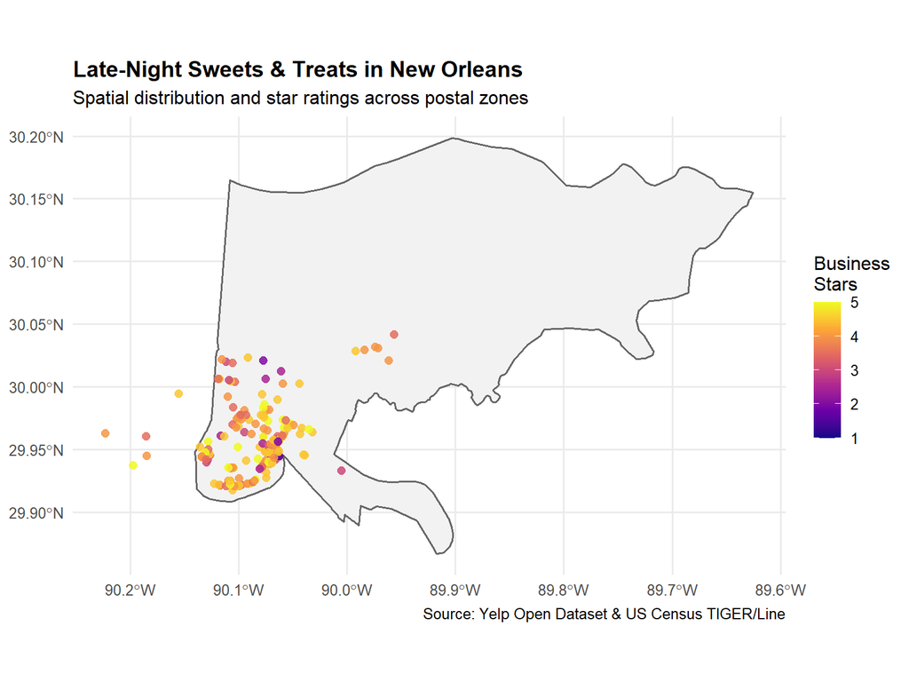

```r
new_orleans_boundary <- louisiana_places |>
  filter(place_name == "New Orleans")

ggplot() +
  geom_sf(data = new_orleans_boundary, fill = "grey95", color = "grey40", linewidth = 0.6) +
  geom_sf(
    data = restaurant_points,
    aes(color = stars),
    alpha = 0.85,
    size = 2.2
  ) +
  scale_color_viridis_c(option = "C", limits = c(1, 5)) +
  labs(
    title = "Late-Night Sweets & Treats in New Orleans",
    subtitle = "Spatial distribution and star ratings across postal zones",
    color = "Business\nStars",
    caption = "Source: Yelp Open Dataset & US Census TIGER/Line"
  ) +
  theme_minimal(base_size = 12) +
  theme(
    plot.title = element_text(face = "bold", size = 14),
    panel.grid.minor = element_blank()
  )
```

```r
zcta_boundaries <- zctas(
  year = 2020,
  cb = TRUE,
  progress_bar = FALSE
) |>
  filter(str_starts(ZCTA5CE20, "70|71")) |>
  st_transform(4326) |>
  select(area_id = ZCTA5CE20, area_name = ZCTA5CE20)

tract_boundaries <- tracts(
  state = "LA",
  county = "071",
  year = 2022,
  cb = TRUE,
  progress_bar = FALSE
) |>
  st_transform(4326) |>
  select(area_id = GEOID, area_name = NAMELSAD)
```

```r
analyze_geo_system <- function(points_sf, boundaries_sf, system_label) {
  joined <- points_sf |>
    st_join(boundaries_sf, join = st_within, left = TRUE) |>
    st_drop_geometry()

  unmatched_count <- sum(is.na(joined$area_id))
  matched_count <- sum(!is.na(joined$area_id))

  area_counts <- joined |>
    filter(!is.na(area_id)) |>
    count(area_id, name = "n_restaurants")

  tibble(
    `Geographic system` = system_label,
    `Number of areas` = n_distinct(boundaries_sf$area_id),
    `Restaurants assigned` = matched_count,
    `Unmatched restaurants` = unmatched_count,
    `Smallest area count` = if (nrow(area_counts) > 0) min(area_counts$n_restaurants) else 0,
    `Largest area count` = if (nrow(area_counts) > 0) max(area_counts$n_restaurants) else 0
  )
}

zcta_metrics <- analyze_geo_system(restaurant_points, zcta_boundaries, "ZIP/ZCTA")
tract_metrics <- analyze_geo_system(restaurant_points, tract_boundaries, "Census Tract")

geo_system_comparison <- bind_rows(zcta_metrics, tract_metrics)

kable(
  geo_system_comparison,
  caption = "Comparison of Candidate Geographic Boundary Systems in New Orleans"
)
```

Comparison of Candidate Geographic Boundary Systems in New Orleans

| Geographic system | Number of areas | Restaurants assigned | Unmatched restaurants | Smallest area count | Largest area count |
| --- | --- | --- | --- | --- | --- |
| ZIP/ZCTA | 675 | 186 | 0 | 1 | 42 |
| Census Tract | 184 | 181 | 5 | 1 | 22 |

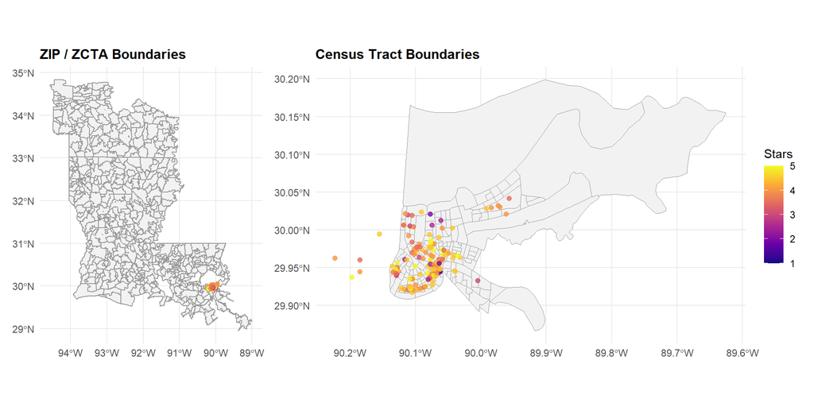

Figure 1: Spatial Comparison of Sweet Treat Establishments: ZCTA vs. Census Tract Boundaries

```r
zcta_joined <- restaurant_points |>
  st_join(zcta_boundaries, join = st_within, left = TRUE)

tract_joined <- restaurant_points |>
  st_join(tract_boundaries, join = st_within, left = TRUE)

p1 <- ggplot() +
  geom_sf(data = zcta_boundaries, fill = "grey95", color = "grey60", linewidth = 0.4) +
  geom_sf(data = zcta_joined, aes(color = stars), alpha = 0.8, size = 1.8) +
  scale_color_viridis_c(option = "C", limits = c(1, 5)) +
  labs(title = "ZIP / ZCTA Boundaries", color = "Stars") +
  theme_minimal() +
  theme(plot.title = element_text(face = "bold", size = 12))

p2 <- ggplot() +
  geom_sf(data = tract_boundaries, fill = "grey95", color = "grey60", linewidth = 0.3) +
  geom_sf(data = tract_joined, aes(color = stars), alpha = 0.8, size = 1.8) +
  scale_color_viridis_c(option = "C", limits = c(1, 5)) +
  labs(title = "Census Tract Boundaries", color = "Stars") +
  theme_minimal() +
  theme(plot.title = element_text(face = "bold", size = 12))

p1 + p2 + plot_layout(guides = "collect")
```

```r
global_avg_stars <- mean(selected_businesses$stars, na.rm = TRUE)

geo_summary <- selected_businesses |>
  filter(!is.na(postal_code) & postal_code != "") |>
  group_by(postal_code) |>
  summarize(
    Restaurant_Count = n(),
    Avg_Stars = round(mean(stars, na.rm = TRUE), 2),
    Total_Reviews = sum(review_count, na.rm = TRUE),
    Adjusted_Score = round(
      (sum(review_count * stars) + 50 * global_avg_stars) / (sum(review_count) + 50), 2
    ),
    .groups = "drop"
  ) |>
  filter(Restaurant_Count > 1) |>
  arrange(desc(Restaurant_Count))

kable(geo_summary, caption = "Performance Summary Across Postal Codes")
```

Performance Summary Across Postal Codes

| postal_code | Restaurant_Count | Avg_Stars | Total_Reviews | Adjusted_Score |
| --- | --- | --- | --- | --- |
| 70130 | 42 | 3.93 | 10664 | 4.01 |
| 70115 | 33 | 4.24 | 7062 | 4.24 |
| 70119 | 24 | 4.10 | 4238 | 4.36 |
| 70118 | 19 | 3.74 | 1102 | 3.75 |
| 70116 | 11 | 4.23 | 1382 | 4.08 |
| 70117 | 11 | 4.55 | 947 | 3.89 |
| 70124 | 11 | 3.82 | 514 | 4.08 |
| 70112 | 6 | 4.25 | 274 | 4.26 |
| 70122 | 6 | 3.33 | 133 | 3.76 |
| 70113 | 5 | 4.50 | 2540 | 4.11 |
| 70127 | 5 | 4.10 | 98 | 4.13 |
| 70123 | 3 | 4.33 | 112 | 4.30 |
| 70125 | 2 | 4.75 | 29 | 4.33 |
| 70131 | 2 | 3.75 | 28 | 3.83 |

Restaurant Count and Performance by Postal Zone

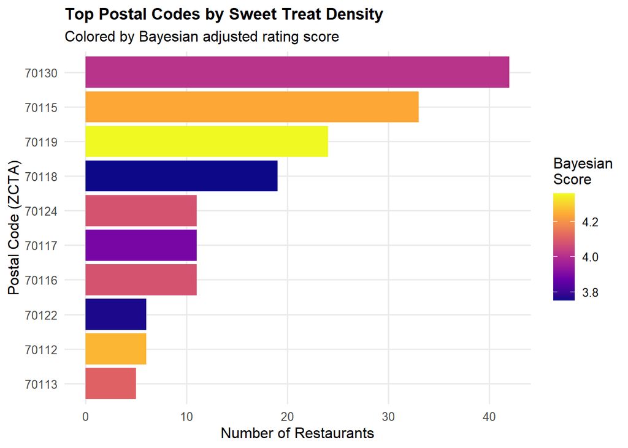

Restaurant Count and Performance by Postal Zone

```r
geo_summary |>
  slice_head(n = 10) |>
  mutate(postal_code = fct_reorder(postal_code, Restaurant_Count)) |>
  ggplot(aes(x = Restaurant_Count, y = postal_code, fill = Adjusted_Score)) +
  geom_col() +
  scale_fill_viridis_c(option = "C", name = "Bayesian\nScore") +
  labs(
    title = "Top Postal Codes by Sweet Treat Density",
    subtitle = "Colored by Bayesian adjusted rating score",
    x = "Number of Restaurants",
    y = "Postal Code (ZCTA)"
  ) +
  theme_minimal(base_size = 12) +
  theme(
    plot.title = element_text(face = "bold", size = 13),
    panel.grid.minor = element_blank()
  )
```

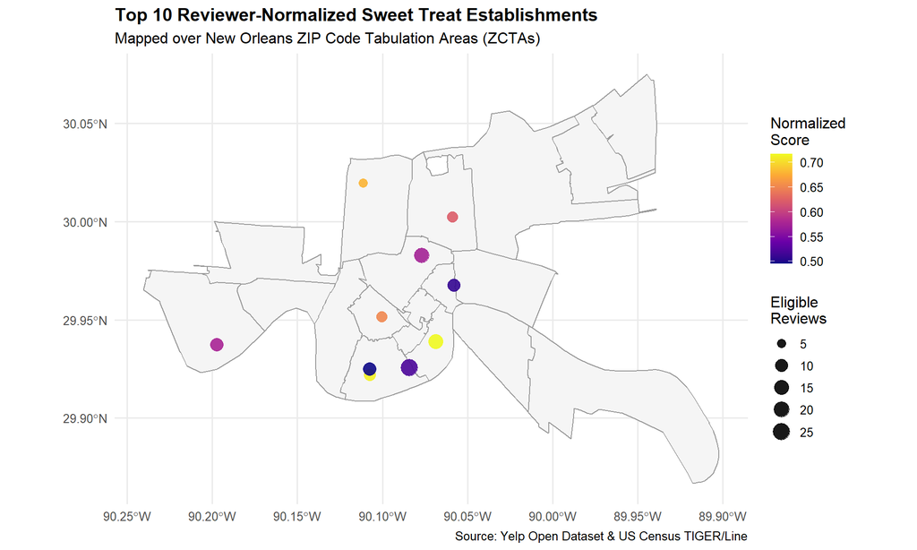

Figure 2: Spatial Distribution of Top 10 Reviewer-Normalized Sweet Treat Establishments Across New Orleans ZCTAs

```r
top_10_sf <- restaurant_summary |>
  filter(
    number_of_reviews_eligible_reviewers >= 5,
    !is.na(longitude),
    !is.na(latitude)
  ) |>
  slice_head(n = 10) |>
  st_as_sf(coords = c("longitude", "latitude"), crs = 4326, remove = FALSE)

nola_zctas <- zcta_bound |>
  filter(area_id %in% unique(selected_businesses$postal_code))

ggplot() +
  geom_sf(data = nola_zctas, fill = "grey96", color = "grey60", linewidth = 0.5) +
  geom_sf(
    data = top_10_sf,
    aes(color = average_normalized_score, size = number_of_reviews_eligible_reviewers),
    alpha = 0.9  ) +
  scale_color_viridis_c(option = "C", name = "Normalized\nScore") +
  scale_size_continuous(range = c(3, 6), name = "Eligible\nReviews") +
  labs(
    title = "Top 10 Reviewer-Normalized Sweet Treat Establishments",
    subtitle = "Mapped over New Orleans ZIP Code Tabulation Areas (ZCTAs)",
    caption = "Source: Yelp Open Dataset & US Census TIGER/Line"  ) +
  theme_minimal(base_size = 12) +
  theme(
    plot.title = element_text(face = "bold", size = 14),
    panel.grid.minor = element_blank(),
    legend.position = "right"
  )
```